# Stimulation experiments

Analysis of stimulation experiments.

```r
library(Seurat)
library(dplyr)
library(ggplot2)
```

Load integrated object. This object has been integrated with CCA, because there was lots of batch effect between the 0hr tissue and the other two experiments (which merged quite well).

```r
load("~/Dropbox/Zoe/scf_version/analysis/healthy_sc/seurat_objects/no_dropletQC/3391/integrated_3391_stimulation_pmaio_unstim_downsampled_cca_kanchor5_scClustViz.RData")
```

Set identities:

```r
Idents(scSeurat) <- "integrated_snn_res.0.4"
```

Check out the UMAP of clusters, original identities, and refined SCINA labels.

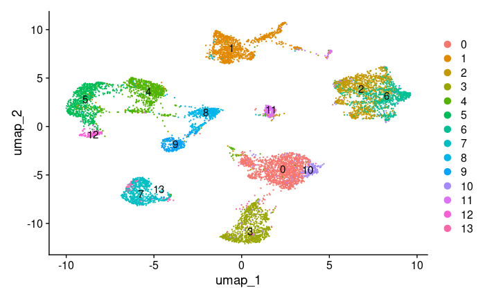

```r
DimPlot(scSeurat, label = TRUE)
```

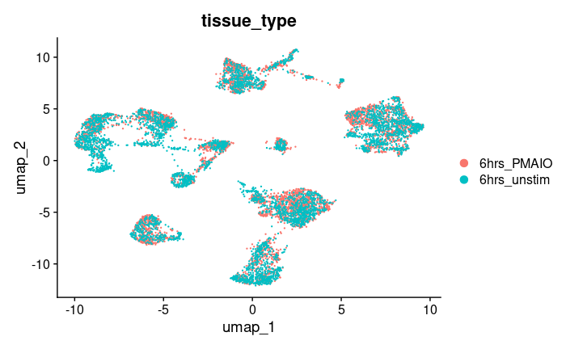

```r
DimPlot(scSeurat, group.by = "tissue_type", label = FALSE)
```

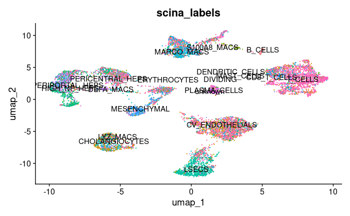

```r
DimPlot(scSeurat, group.by = "scina_labels", label = TRUE) & NoLegend()
```

Look at tissue-type per cluster on a proportional level:

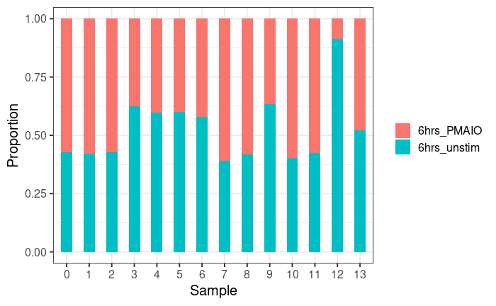

```r
pt <- table(Idents(scSeurat), scSeurat$tissue_type)
pt <- as.data.frame(pt)
ggplot(pt, aes(x = Var1, y = Freq, fill = Var2)) +
  theme_bw(base_size = 15) +
  geom_col(position = "fill", width = 0.5) +
  xlab("Sample") +
  ylab("Proportion") +
  theme(legend.title = element_blank())
```

Look for T-cell signatures.

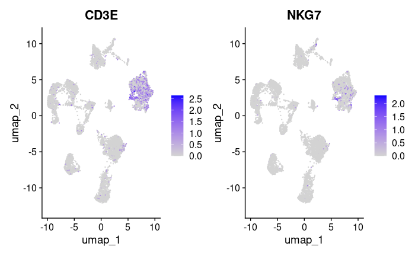

```r
FeaturePlot(scSeurat, features = c("CD3E", "NKG7"))
```

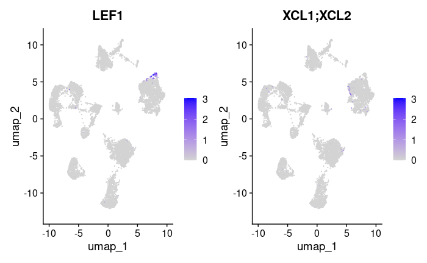

```r
FeaturePlot(scSeurat, features = c("LEF1", "XCL1;XCL2"))
```

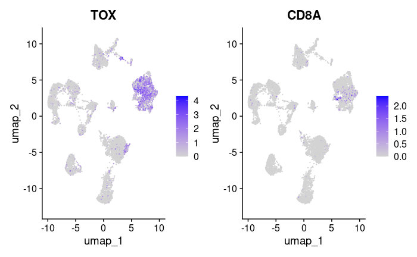

```r
FeaturePlot(scSeurat, features = c("TOX", "CD8A"))
```

Look for macrophage signatures:

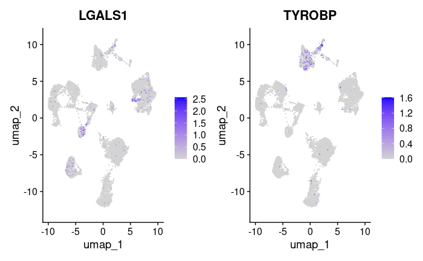

```r
FeaturePlot(scSeurat, features = c("LGALS1", "TYROBP"))
```

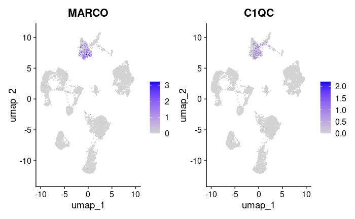

```r
FeaturePlot(scSeurat, features = c("MARCO", "C1QC"))
```

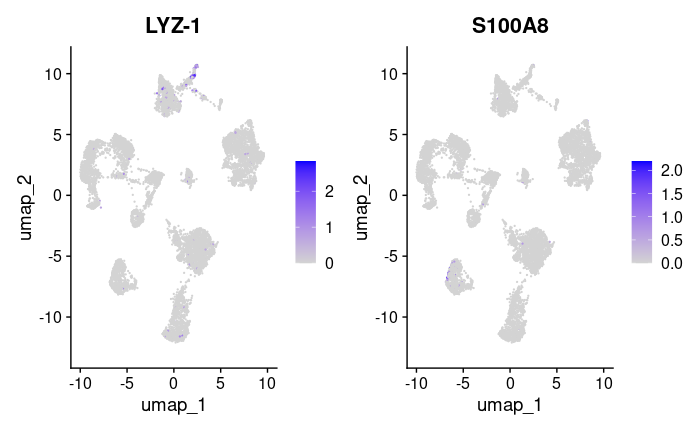

```r
FeaturePlot(scSeurat, features = c("LYZ-1", "S100A8"))
```

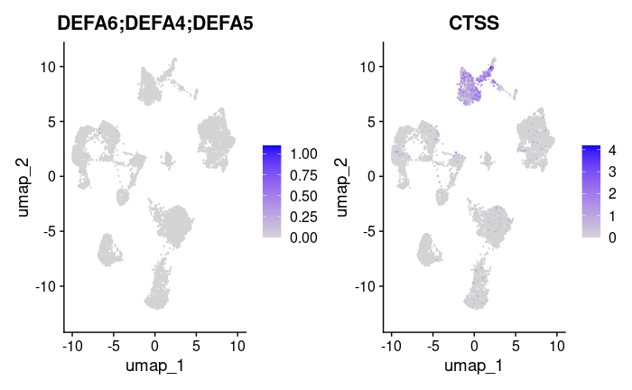

```r
FeaturePlot(scSeurat, features = c("DEFA6;DEFA4;DEFA5", "CTSS"))
```

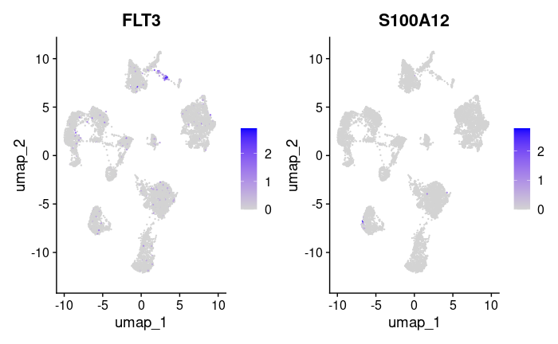

```r
FeaturePlot(scSeurat, features = c("FLT3", "S100A12"))
```

Look for B and plasma cell signatures

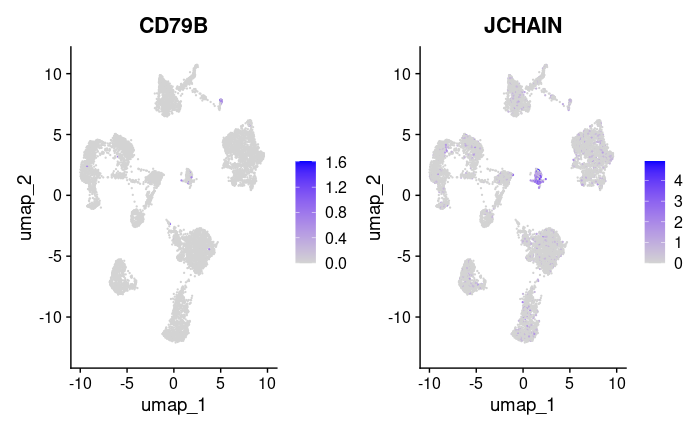

```r
FeaturePlot(scSeurat, features = c("CD79B", "JCHAIN"))
```

```r
# Isolate DE genes
clust11 <- sCVdata_list$res.0.4@DEvsRest$`12`[order(sCVdata_list$res.0.4@DEvsRest$`12`$Wstat,
                                                    decreasing = TRUE), ]
rownames(clust11)[1:50]
```

```
 [1] "PAH"                                      "LOC114082496"                             "TDO2"                                     "MAT1A"                                    "GYS2"
 [6] "SLCO1B3;SLCO1B3-SLCO1B7;SLCO1B7;SLCO1B1"  "FBP1"                                     "CPS1"                                     "SLC2A2"                                   "ALDOB"
[11] "MTSS1"                                    "IGFBP1"                                   "CYP3A4;CYP3A7-CYP3A51P;CYP3A7-2"          "mikado.WCK01-AAH20201022-F8-rsc00143G668" "PCK1"
[16] "SHMT1"                                    "CYP3A4;CYP3A7-CYP3A51P;CYP3A7"            "ARG1"                                     "CYP3A4;CYP3A7-CYP3A51P;CYP3A7-3"          "LOC107139912"
[21] "ALB-1"                                    "SLC38A4"                                  "LOC107139914"                             "SORBS2"                                   "TAT"
[26] "C5-1"                                     "KLKB1"                                    "Slc22a19-1"                               "G6PC1"                                    "RBP4"
[31] "AGMO"                                     "HSD17B11"                                 "CMBL"                                     "SLC25A13"                                 "ZBTB16"
[36] "C8G"                                      "PYGL"                                     "HSD11B1"                                  "mikado.WCK01-AAH20201022-F8-rsc00060G101" "CES3"
[41] "MTARC2"                                   "IDO2"                                     "AQP9"                                     "ACACB"                                    "GOT1"
[46] "CFI"                                      "NR1I2"                                    "ABCB11"                                   "SOX5"                                     "BHMT2"
```

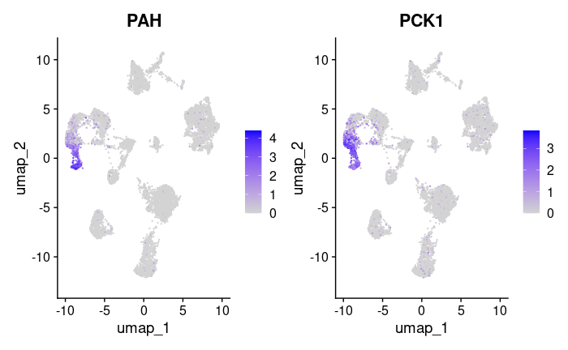

```r
FeaturePlot(scSeurat, features = c("PAH","PCK1"))
```

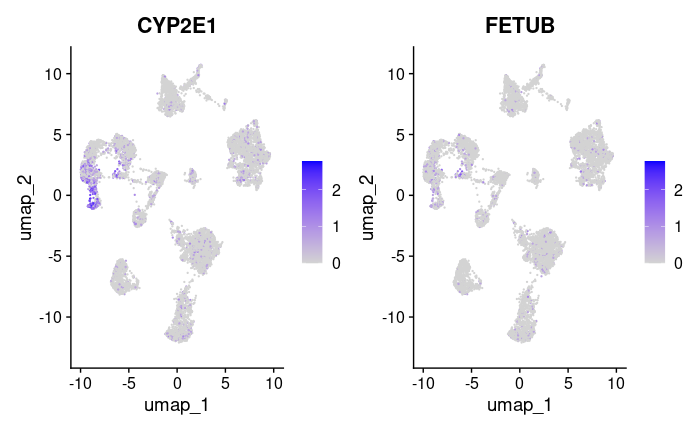

```r
FeaturePlot(scSeurat, features = c("CYP2E1","FETUB"))
```

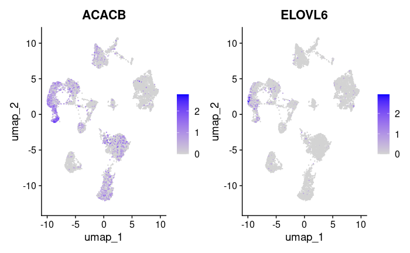

```r
FeaturePlot(scSeurat, features = c("ACACB","ELOVL6"))
```

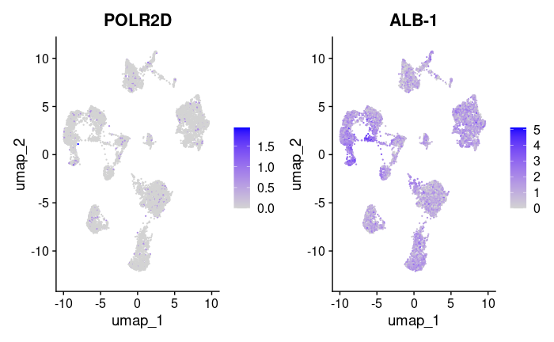

```r
FeaturePlot(scSeurat, features = c("POLR2D", "ALB-1"))
```

Let’s look at some of the key markers that Sonya sent: IL2, IL4, IL6, IL7, IL10, IL12A, TGFB

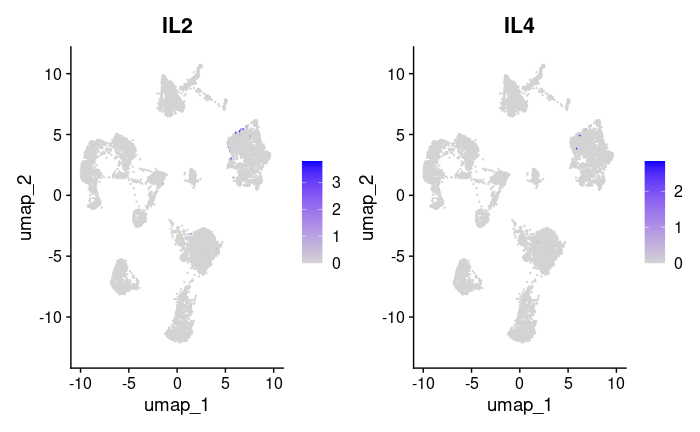

```r
FeaturePlot(scSeurat, features = c("IL2", "IL4"))
```

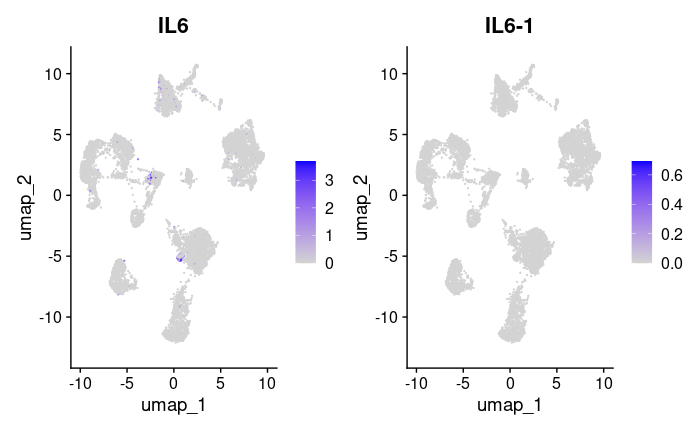

```r
FeaturePlot(scSeurat, features = c("IL6", "IL6-1"))
```

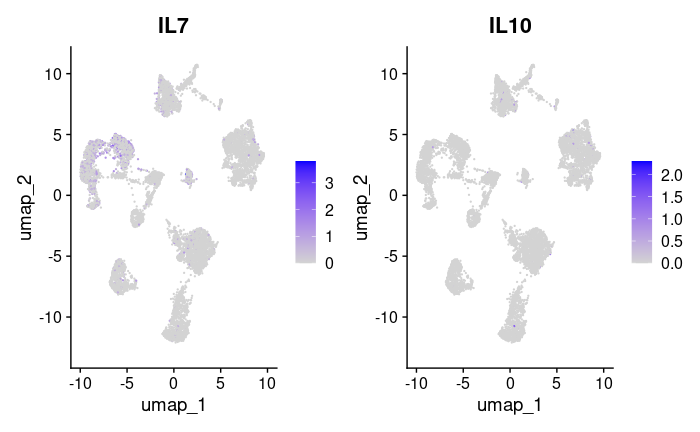

```r
FeaturePlot(scSeurat, features = c("IL7", "IL10"))
```

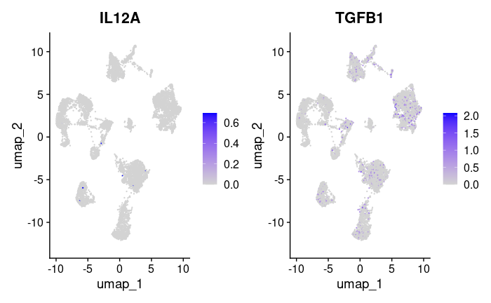

```r
FeaturePlot(scSeurat, features = c("IL12A", "TGFB1"))
```

It’s pretty hard to see which cytokines are expressed in which samples, so I’m going to try splitting up the samples.

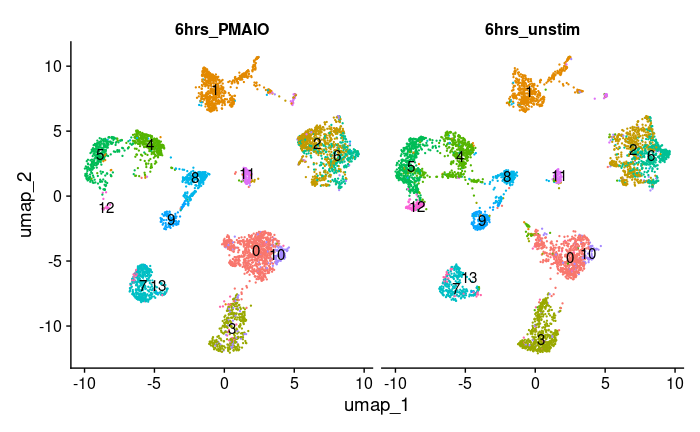

```r
DimPlot(scSeurat, split.by = "tissue_type", label = TRUE) & NoLegend()
```

Now let’s take a look at the features on this split plot.

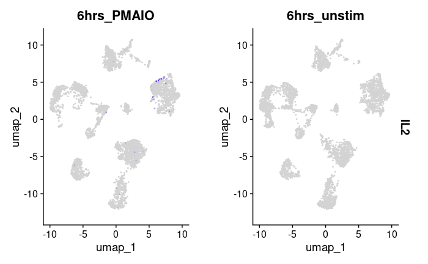

```r
FeaturePlot(scSeurat, feature = "IL2", split.by = "tissue_type") # Only in PMAIO cluster 2
```

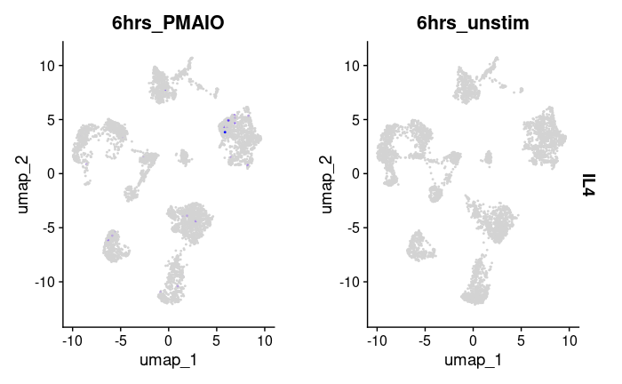

```r
FeaturePlot(scSeurat, feature = "IL4", split.by = "tissue_type") # Only in PMAIO cluster 2
```